# Answers Lab3

Rodrigo Vera

12/6/2018

# Solution for the Laboratory 3

This is an R Markdown document including the solutions to the laboratory 3 for the Data Driven Security subject of the Master in CyberSecurity Management.

## Crawling y Scrapping

Using the functions implemented in the file `code.R`.

```r
source("./code.R")
```

### 1.1 Obtención de la página web

Con la siguiente función se obtiene la página web:

```r
PagWeb <- ObtenerWeb()
```

### 1.2 Análisis del contenido de la web

Se obtiene contenido de la página web con:

```r
contenido <- ObtenerContenido(PagWeb$web_xml)
```

Por ejemplo, el título de la página web es: **MediaWiki** y usa estas DNS: **//login.wikimedia.org, //meta.wikimedia.org**

Se estudia la estructura y el contenido de los datos para su posterior análisis.

### 1.3. Extracción de enlaces

Para listar los enlaces se utiliza la siguiente funcion:

```r
enlaces <- ObtenerEnlaces(PagWeb$web_xml)
```

Obteniendo los siguientes enlaces

```
##                   valor                                      enlace
## 1    Jump to navigation                                    #mw-head
## 2        Jump to search                                   #p-search
## 3                  free https://en.wikipedia.org/wiki/Free_software
## 4           open source   https://en.wikipedia.org/wiki/Open_source
## 5                  wiki          https://en.wikipedia.org/wiki/Wiki
## 6                   PHP                     https://secure.php.net/
## 7             Wikipedia     https://en.wikipedia.org/wiki/Main_Page
## 8  Wikimedia Foundation  https://foundation.wikimedia.org/wiki/Home
## 9      many other wikis                 /wiki/Sites_using_MediaWiki
## 10   communication page                         /wiki/Communication
```

Se muestran los 10 primeros enlaces de **184**

### 1.4 Exploración de enlaces

Para poder regularizar los enlaces, se utilizó:

```r
enlaces_regulados <- RegularUrl(enlaces)
url_raros <- UrlRaras(enlaces)
```

Obteniendo los siguientes enlaces regularizados:

```
##         valor     tipo          dominio codigo_estado
## 3        free Absoluta en.wikipedia.org           200
## 4 open source Absoluta en.wikipedia.org           200
## 5        wiki Absoluta en.wikipedia.org           200
##                                        enlace
## 3 https://en.wikipedia.org/wiki/Free_software
## 4   https://en.wikipedia.org/wiki/Open_source
## 5          https://en.wikipedia.org/wiki/Wiki
##                                           url
## 3 https://en.wikipedia.org/wiki/Free_software
## 4   https://en.wikipedia.org/wiki/Open_source
## 5          https://en.wikipedia.org/wiki/Wiki
```

```
##                  valor    enlace
## 1   Jump to navigation  #mw-head
## 2       Jump to search #p-search
## 119            English         #
```

### 2.1 Histograma

Este es un histograma, que va en función de los dominios y el tipo de URL almacenado en la página

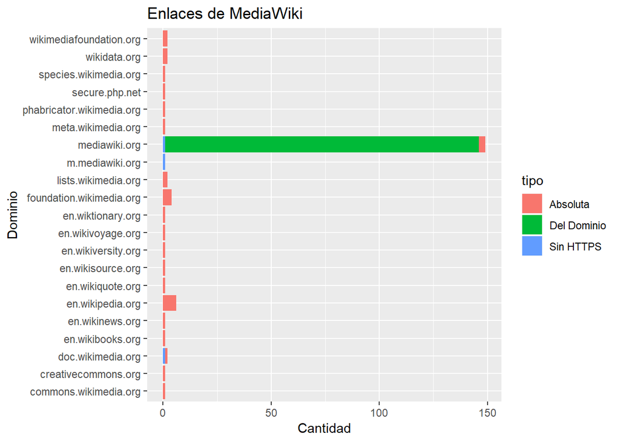

```r
library(ggplot2)
ggplot(data.frame(enlaces_regulados), aes(x=dominio,fill=tipo))  +
  geom_bar() +
  coord_flip() +
  xlab("Dominio") +
  ylab("Cantidad") +
  ggtitle(paste0("Enlaces de ", contenido$titulo))
```

### 2.2 Un gráfico de barras

Con este grafico de barras se puede ver la relación entre el dominio y el tipo de URL de la página

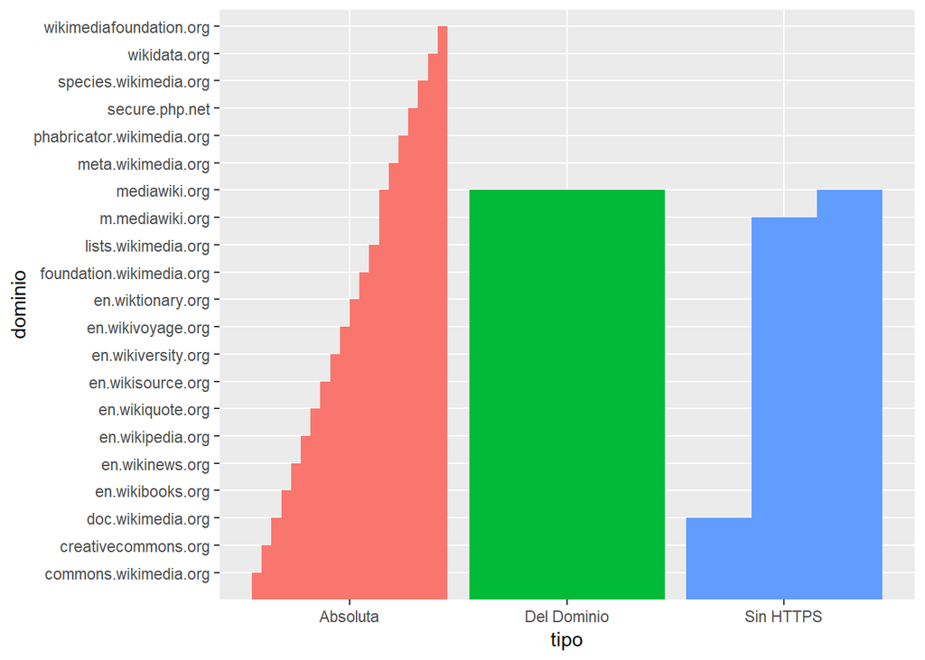

```r
ggplot(data=enlaces_regulados, aes(x=tipo, y=dominio, fill=tipo)) +
  geom_bar(stat="identity", position="dodge")+ guides(fill=FALSE)
```

### 2.3 Pie Chart

Con el siguiente grafico se puede observar el estado de los enlaces.

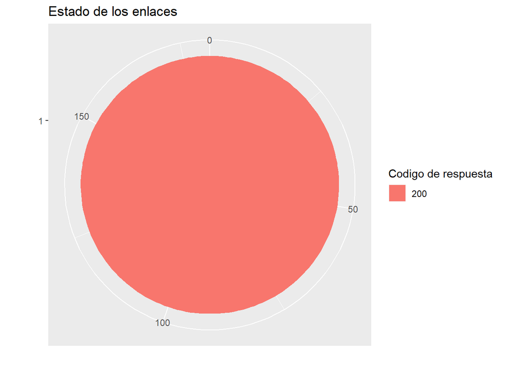

```r
ggplot(enlaces_regulados, aes(x = factor(1), fill = factor(codigo_estado))) +
  geom_bar(width = 1) + coord_polar(theta = "y") + labs(fill="Codigo de respuesta") +
  ggtitle("Estado de los enlaces") + xlab("") + ylab("")
```